# Consumer attitude towards fish sauce products

Xuan Pham

12/17/2019

# 1. Setting up the working environment

# 2. Import data

# 3. Sample structure understanding

## 3.1 Categorical variables

Majority of respondents are female in their 20s (20-24 yo), obtained University degree, having full-time jobs and originally from the South.

### 3.1.1 Sample structure table summary

| Variable | Level | No. of respondents | % Respondents |
| --- | --- | --- | --- |
| Age range | 20-24 yo | 173 | 57.67 |
| Age range | Above 35 yo | 71 | 23.67 |
| Age range | 25-35 yo | 56 | 18.67 |
| Education level | University | 267 | 89.00 |
| Education level | High school | 31 | 10.33 |
| Education level | Below high school | 2 | 0.67 |
| Gender | Female | 199 | 66.33 |
| Gender | Male | 101 | 33.67 |
| Job | Full-time | 155 | 51.67 |
| Job | Student | 103 | 34.33 |
| Job | Part-time | 33 | 11.00 |
| Job | Housework | 9 | 3.00 |
| Native village | South | 195 | 65.00 |
| Native village | Central | 66 | 22.00 |
| Native village | North | 39 | 13.00 |

### 3.1.2 Sample structure plot

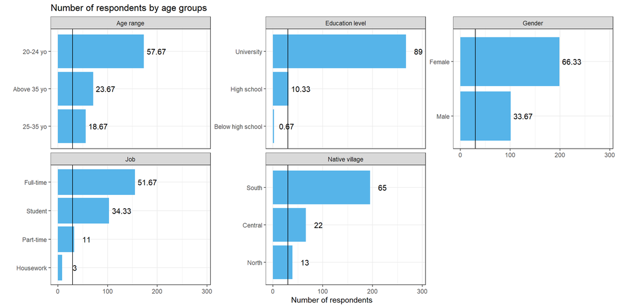

## 3.2 Continuous variables

Respondent age is not normally distributed. 1/3 respondents are 22 years old.

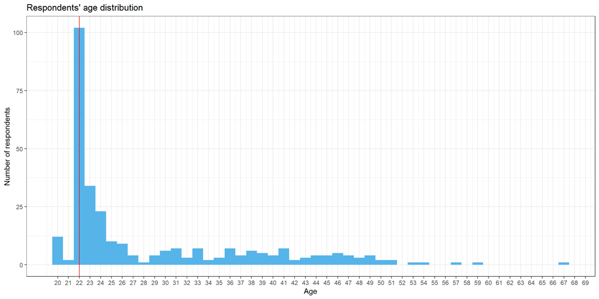

## 3.3 Continuous vs. categorical variables

Female respondents age is extremely right skewed.

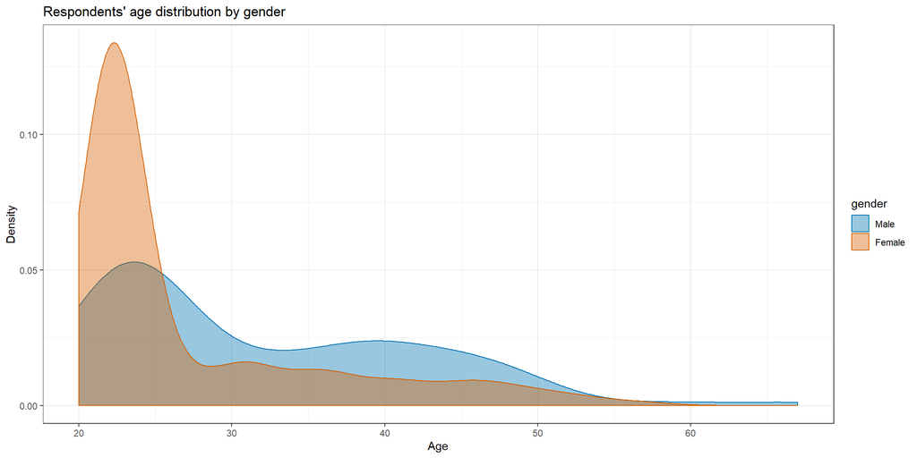

Age distributions of those who are from the South and Central are wider spread than the North group.

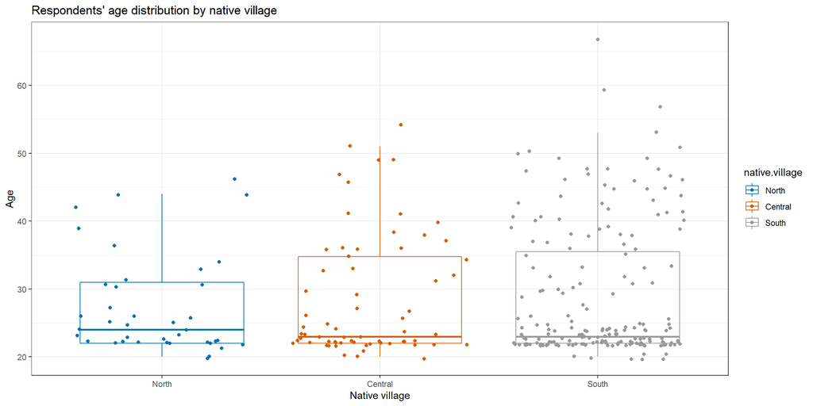

# 4. Data cleaning

Coding error is spotted! Each variable in brand section should have two levels only. Khai hoan brand has 4 levels.

```
      ID                phu.quoc        phan.thiet     nam.ngu
 Length:300         kh.pq   :256   kh.pt     :282   kh.nn  :150
 Class :character   phu.quoc: 44   phan.thiet: 18   nam.ngu:150
 Mode  :character

     hanh.phuc        thanh.phong      de.nhi       chinsu       co.hau
 hanh.phuc: 19   kh.tp      :299   de.nhi : 25   chinsu: 56   co.hau:  1
 kh.hp    :281   thanh.phong:  1   kh.dnhi:275   kh.cs :244   kh.ch :299


      hung.thinh     ba.mien        cholimex       nha.trang
 hung.thinh: 39   ba.mien:  2   cholimex:  3   kh.nt    :292
 kh.ht     :261   kh.bm  :298   kh.cho  :297   nha.trang:  8


      hong.thanh      khai.hoan        thien.huong      tu.tuyet
 hong.thanh:  4   k        :  7   kh.th      :298   kh.tt   :298
 kh.hthanh :296   kh.kh    :259   thien.huong:  2   tu.tuyet:  2
                  khai.hoan:  5
                  NA's     : 29
      lien.thanh
 kh.lt     :283
 lien.thanh: 17
```

Nam Ngu is the most popular brand and almost triple the second player - Chinsu in terms of the number of responses.

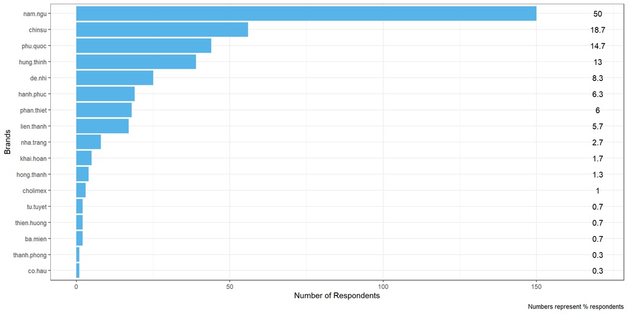

There are few respondents gave more than the required number of responses (maximum is 2).

| Respondent ID | Brand 1 | Brand 2 | Brand 3 | Brand 4 | Number of brands declared |
| --- | --- | --- | --- | --- | --- |
| KS2_29 | phu.quoc | phan.thiet | nam.ngu | hung.thinh | 4 |
| KS2_111 | phu.quoc | nam.ngu | nha.trang | NA | 3 |
| KS2_130 | nam.ngu | chinsu | cholimex | NA | 3 |
| KS2_181 | hanh.phuc | chinsu | hung.thinh | NA | 3 |
| KS2_224 | phu.quoc | nam.ngu | lien.thanh | NA | 3 |
| KS2_255 | hung.thinh | tu.tuyet | lien.thanh | NA | 3 |
| KS2_109 | phu.quoc | hung.thinh | NA | NA | 2 |
| KS2_110 | hung.thinh | cholimex | NA | NA | 2 |
| KS2_113 | de.nhi | hung.thinh | NA | NA | 2 |
| KS2_115 | nam.ngu | de.nhi | NA | NA | 2 |

# 5. Data exploration

## 5.1 Key influencing factors

Average rating score of 6 key factors:

| Health | Sensory | Tradition | Quality | Price | Convenience |
| --- | --- | --- | --- | --- | --- |
| 3.95 | 4.09 | 3.98 | 4.16 | 4 | 4.08 |

**Quality** seems to be the most influencing factor.

The challenge of visualing ordinal categorical variables:

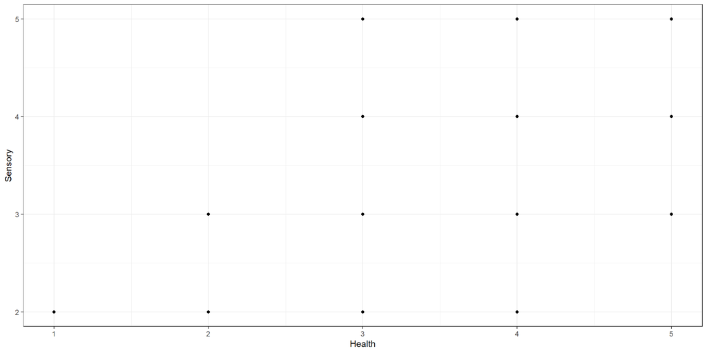

Using ‘jitter’ trick…

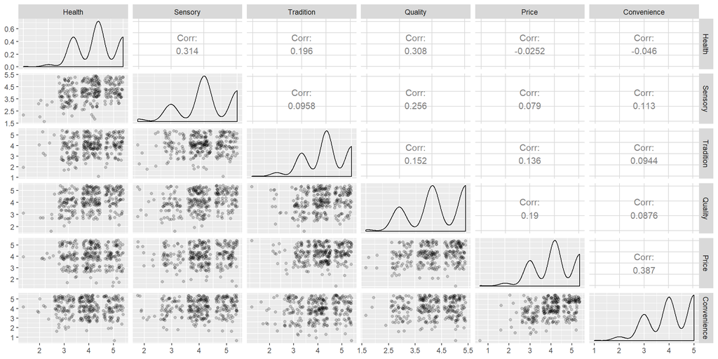

… or using dimension reduction technique?

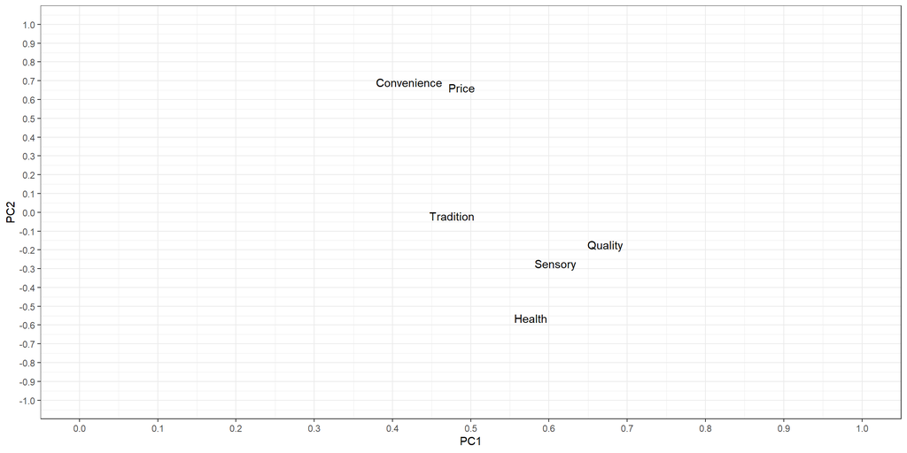

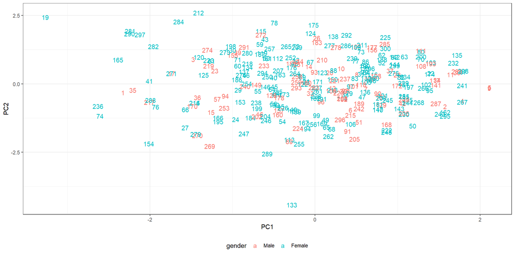

**Revealing special cases:**

**Respondent 19:**

| Health | Sensory | Tradition | Quality | Price | Convenience |
| --- | --- | --- | --- | --- | --- |
| 1 | 2 | 2 | 3 | 4 | 4 |

**Respondent 133:**

| Health | Sensory | Tradition | Quality | Price | Convenience |
| --- | --- | --- | --- | --- | --- |
| 5 | 5 | 5 | 5 | 1 | 1 |

## 5.2 Important factors

Looking into sub-factors, the **product origin** seems to be the most concerning factor when choosing fish sauce products.

| Factors | Value |
| --- | --- |
| **Convenience** |  |
| Can be bought in shops close to where I live or work | 3.85 |
| Is easily available in shops and supermarkets | 4.04 |
| Is easy to prepare | 3.83 |
| Takes no time to prepare | 3.91 |
| **Health** |  |
| Contains lots of protein, vitamins, omega-3, iron and lysine | 3.9 |
| Eating with fish sauce will help us eat more, thus providing more active energy | 3.68 |
| Keeps me healthy | 3.82 |
| **Price** |  |
| Is cheap | 3.25 |
| Is good value for money | 4.02 |
| Is not expensive | 3.65 |
| **Quality and safety** |  |
| Conform to Vietnam or global quality standard | 3.8 |
| Get certification of Vietnam high quality goods by consumers | 3.8 |
| Has a clear origin of production | 4.18 |
| Has Eco-friendly packaging | 3.57 |
| **Sensory appeal** |  |
| Distinctive brownish color | 3.7 |
| Eye-catching packaging | 3.58 |
| Has a pleasant texture | 3.7 |
| Smells nice | 3.91 |
| Tastes good | 4.03 |
| **Traditional value** |  |
| Be processed/prepared in a special way | 3.9 |
| Has origin of materials (geographical indications) | 4.23 |
| Is associated to specific celebrations of my country/family | 3.55 |
| Is familiar with me and my family | 3.74 |
| Is special product that reflects the nation or local culture | 4.06 |

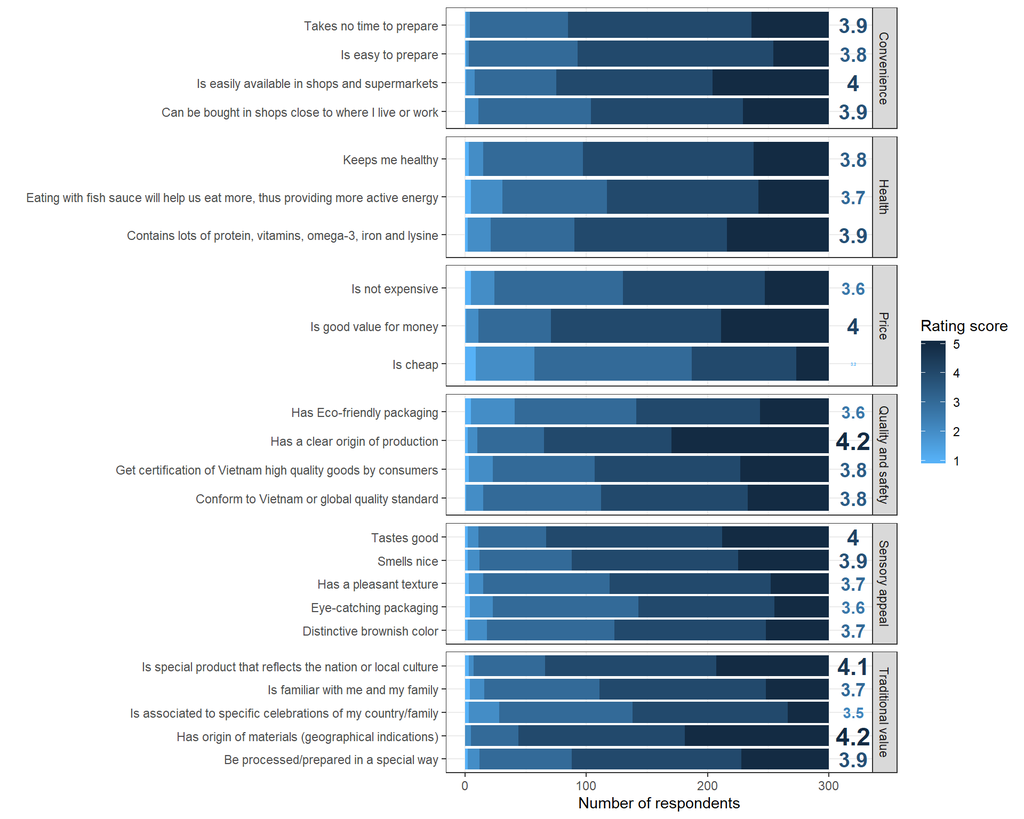

The origin factor is highly important for both male and female groups. Male respondents seem to give higher scores in most of the factors compared to their counterparts. However, female respondents seem to care more about whether the products are available in shops, keeping them healthy and reflecting the local culture than male.

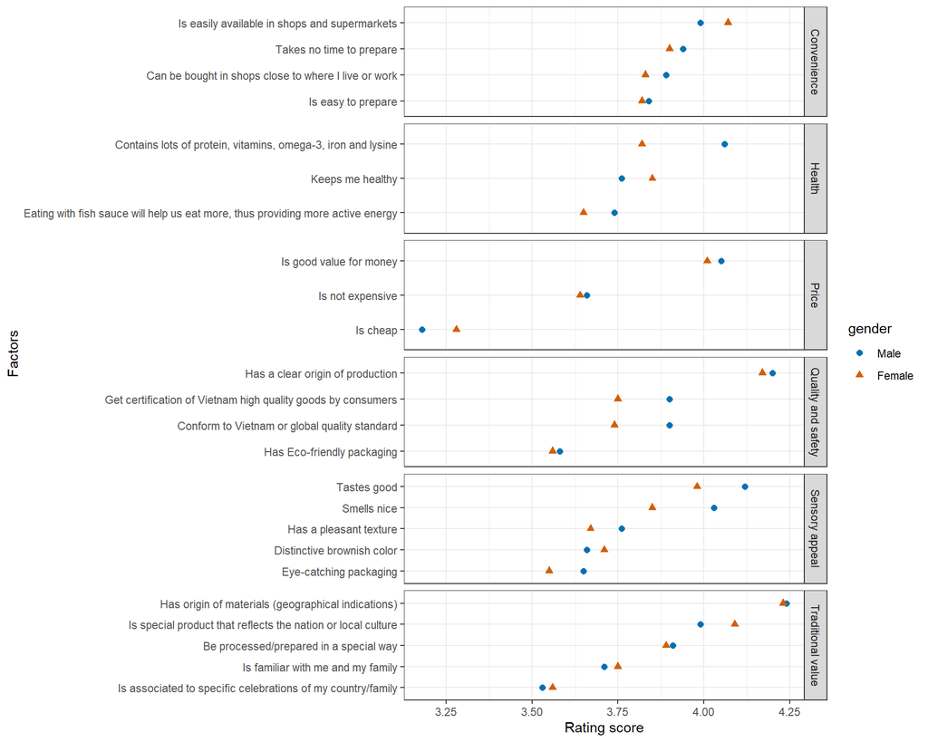

| Factors | Male | Female |
| --- | --- | --- |
| **Convenience** |  |  |
| Can be bought in shops close to where I live or work | 3.89 | 3.83 |
| Is easily available in shops and supermarkets | 3.99 | 4.07 |
| Is easy to prepare | 3.84 | 3.82 |
| Takes no time to prepare | 3.94 | 3.9 |
| **Health** |  |  |
| Contains lots of protein, vitamins, omega-3, iron and lysine | 4.06 | 3.82 |
| Eating with fish sauce will help us eat more, thus providing more active energy | 3.74 | 3.65 |
| Keeps me healthy | 3.76 | 3.85 |
| **Price** |  |  |
| Is cheap | 3.18 | 3.28 |
| Is good value for money | 4.05 | 4.01 |
| Is not expensive | 3.66 | 3.64 |
| **Quality and safety** |  |  |
| Conform to Vietnam or global quality standard | 3.9 | 3.74 |
| Get certification of Vietnam high quality goods by consumers | 3.9 | 3.75 |
| Has a clear origin of production | 4.2 | 4.17 |
| Has Eco-friendly packaging | 3.58 | 3.56 |
| **Sensory appeal** |  |  |
| Distinctive brownish color | 3.66 | 3.71 |
| Eye-catching packaging | 3.65 | 3.55 |
| Has a pleasant texture | 3.76 | 3.67 |
| Smells nice | 4.03 | 3.85 |
| Tastes good | 4.12 | 3.98 |
| **Traditional value** |  |  |
| Be processed/prepared in a special way | 3.91 | 3.89 |
| Has origin of materials (geographical indications) | 4.24 | 4.23 |
| Is associated to specific celebrations of my country/family | 3.53 | 3.56 |
| Is familiar with me and my family | 3.71 | 3.75 |
| Is special product that reflects the nation or local culture | 3.99 | 4.09 |